# Exploratory Data Analysis of Hsu et al bACEseq

Gaja Matassa

Date: April 29, 2025

```r
for (i in 1:length(params))
  print(paste('Parameter:', names(params)[i], ' - Value:', params[[i]], '- Class:', class(params[[i]])))
## [1] "Parameter: InputFolder  - Value: ~/DataDir/7.EscapeesExploration/bACEseq_Hsu - Class: character"
## [1] "Parameter: OutputFolder  - Value: ~/DataDir/7.EscapeesExploration/bACEseq_Hsu/Output/ - Class: character"
```

```r
InputFolder <- params$InputFolder
OutputFolder <- params$OutputFolder

if (dir.exists(OutputFolder) == FALSE) {
  dir.create(OutputFolder, recursive=TRUE)
}
```

**Colors for figures**

```r
# sample_colors <- c("3_EG2_SL" = "#ff7f00", "3_EG9_SL" = "#ff7f00", "3_EG31_SL" = "#ff7f00",
#                    "2S" = "#dd1c77", "3S" = "#dd1c77", "5S" = "#dd1c77", "4S" = "#dd1c77",
#                    "2M" = "#377eb8", "3M" = "#377eb8", "5M" = "#377eb8", "4M" = "#377eb8",
#                    "2P" = "#4daf4a", "3P" = "#4daf4a", "5P" = "#4daf4a")
#
cellTypes_colors <- c(hESC_KO ="#dd1c77", D4hPGCLC ="#4daf4a", hESC = "#ff7f00")
```

# 1. Loading data

```r
bdg_files <-  list.files(path = InputFolder, pattern = '*sorted.bedGraph', full.names = TRUE) #output from our preprocessing
```

Creation of metadata from file names

```r
sample_anno <- data.frame("SampleGEO" = sapply(strsplit(basename(bdg_files), split = "-|_"), function(x) x[1]),
           "Line" = c(sapply(strsplit(basename(bdg_files), split = "-|_")[1:10], function(x) x[11]), sapply(strsplit(basename(bdg_files), split = "-|_")[11:13], function(x) x[2])),
           "TET1KO" = c(rep(FALSE,10), rep(TRUE,3)),
           "Type" = c(sapply(strsplit(basename(bdg_files), split = "-|_")[1:10], function(x) x[13]),
                          paste0(sapply(strsplit(basename(bdg_files), split = "-|_")[11:13], function(x) x[5]), "_KO")),
           "Replicate" = c(sapply(strsplit(basename(bdg_files), split = "-|_")[1:2], function(x) x[15]),
                           sapply(strsplit(basename(bdg_files), split = "-|_")[3:5], function(x) x[14]),
                           sapply(strsplit(basename(bdg_files), split = "-|_")[6:7], function(x) x[15]),
                           sapply(strsplit(basename(bdg_files), split = "-|_")[8:10], function(x) x[14]),
                           sapply(strsplit(basename(bdg_files), split = "-|_")[11:13], function(x) x[4])),
           #"Sequencing" = rep("WGBS", length(bdg_files)),
           #"Day" = c(sapply(strsplit(basename(bdg_files), split = "-|_")[1:10], function(x) x[14]), NA, NA, NA)
           "FileName" = basename(bdg_files))
sample_anno$SampleID <- paste(sample_anno$Line, sample_anno$Type, sample_anno$Replicate, sep = "_")

if(!any(duplicated(sample_anno$SampleID))){
  rownames(sample_anno) <- sample_anno$SampleID
}else{stop("Duplicated sample names!")}
```

Match order

```r
bdg_files<-bdg_files[order(match(basename(bdg_files), sample_anno$FileName))]
```

# 2. Reading bedgraph files with `read.bismark` from **bsseq** package

## 2.1 Generation of BSseq object

`strandCollapse = FALSE` because MethylDackel has an option to destrand data when methylation calls are made so that the output is already destranded.

```r
if(identical(basename(bdg_files), sample_anno$FileName)){
  bsseq_obj = bsseq::read.bismark(
      files = bdg_files,
      colData = sample_anno,
      rmZeroCov = FALSE,
      strandCollapse = FALSE #false if MethylDackel is used because MethylDackel has an option to destrand data when methylation calls are made so that the output is already destranded.
  )
} else{stop("Sample names don't match between Bedgraph file and metadata")}
```

- The number of samples in the BSSeq object is 13.
- The number of CpGs in the BSSeq object is 54853237.

## 2.2 Exploration of BSseq object

```r
bsseq::pData(bsseq_obj)
```

```
## DataFrame with 13 rows and 7 columns
##                          SampleGEO        Line    TET1KO        Type
##                        <character> <character> <logical> <character>
## UCLA1_hESC_rep1         GSM6759276       UCLA1     FALSE        hESC
## UCLA1_hESC_rep3         GSM6759277       UCLA1     FALSE        hESC
## UCLA1_D4hPGCLC_rep1     GSM6759278       UCLA1     FALSE    D4hPGCLC
## UCLA1_D4hPGCLC_rep2     GSM6759279       UCLA1     FALSE    D4hPGCLC
## UCLA1_D4hPGCLC_rep3     GSM6759280       UCLA1     FALSE    D4hPGCLC
## ...                            ...         ...       ...         ...
## UCLA2_D4hPGCLC_rep2     GSM6759284       UCLA2     FALSE    D4hPGCLC
## UCLA2_D4hPGCLC_rep3     GSM6759285       UCLA2     FALSE    D4hPGCLC
## UCLA1_hESC_KO_CDKO1102  GSM6759286       UCLA1      TRUE     hESC_KO
## UCLA1_hESC_KO_CDKO1105  GSM6759287       UCLA1      TRUE     hESC_KO
## UCLA1_hESC_KO_CDKO1312  GSM6759288       UCLA1      TRUE     hESC_KO
##                          Replicate               FileName
##                        <character>            <character>
## UCLA1_hESC_rep1               rep1 GSM6759276_FMH-011-E..
## UCLA1_hESC_rep3               rep3 GSM6759277_FMH-011-E..
## UCLA1_D4hPGCLC_rep1           rep1 GSM6759278_FMH-011-E..
## UCLA1_D4hPGCLC_rep2           rep2 GSM6759279_FMH-011-E..
## UCLA1_D4hPGCLC_rep3           rep3 GSM6759280_FMH-011-E..
## ...                            ...                    ...
## UCLA2_D4hPGCLC_rep2           rep2 GSM6759284_FMH-011-E..
## UCLA2_D4hPGCLC_rep3           rep3 GSM6759285_FMH-011-E..
## UCLA1_hESC_KO_CDKO1102    CDKO1102 GSM6759286_UCLA1-hTE..
## UCLA1_hESC_KO_CDKO1105    CDKO1105 GSM6759287_UCLA1-hTE..
## UCLA1_hESC_KO_CDKO1312    CDKO1312 GSM6759288_UCLA1-hTE..
##                                      SampleID
##                                   <character>
## UCLA1_hESC_rep1               UCLA1_hESC_rep1
## UCLA1_hESC_rep3               UCLA1_hESC_rep3
## UCLA1_D4hPGCLC_rep1       UCLA1_D4hPGCLC_rep1
## UCLA1_D4hPGCLC_rep2       UCLA1_D4hPGCLC_rep2
## UCLA1_D4hPGCLC_rep3       UCLA1_D4hPGCLC_rep3
## ...                                       ...
## UCLA2_D4hPGCLC_rep2       UCLA2_D4hPGCLC_rep2
## UCLA2_D4hPGCLC_rep3       UCLA2_D4hPGCLC_rep3
## UCLA1_hESC_KO_CDKO1102 UCLA1_hESC_KO_CDKO1102
## UCLA1_hESC_KO_CDKO1105 UCLA1_hESC_KO_CDKO1105
## UCLA1_hESC_KO_CDKO1312 UCLA1_hESC_KO_CDKO1312
```

`bsseq` package assumes that the following data has been extracted from alignments:

1. genomic positions, including chromosome and location, for methylation loci.The genomic positions are stored in the bsseq object as a `GRanges` object. `GRanges` are general genomic regions; they represent a single base methylation loci as an interval of width 1 (which may seem a bit strange, but they said there are good reasons for this).

```r
head(GenomicRanges::granges(bsseq_obj))
```

```
## GRanges object with 6 ranges and 0 metadata columns:
##       seqnames    ranges strand
##          <Rle> <IRanges>  <Rle>
##   [1]     chr1     10468      *
##   [2]     chr1     10469      *
##   [3]     chr1     10470      *
##   [4]     chr1     10471      *
##   [5]     chr1     10483      *
##   [6]     chr1     10484      *
##   -------
##   seqinfo: 177 sequences from an unspecified genome; no seqlengths
```

**Methylation calls are from these chromosomes:**

```r
levels(bsseq_obj@rowRanges@seqnames@values)
```

```
##   [1] "chr1"          "chr2"          "chr3"          "chr4"
##   [5] "chr5"          "chr6"          "chr7"          "chr8"
##   [9] "chr9"          "chr10"         "chr11"         "chr12"
##  [13] "chr13"         "chr14"         "chr15"         "chr16"
##  [17] "chr17"         "chr18"         "chr19"         "chr20"
##  [21] "chr21"         "chr22"         "chrX"          "chrY"
##  [25] "chrMT"         "chrGL000008.2" "chrGL000009.2" "chrGL000194.1"
##  [29] "chrGL000195.1" "chrGL000205.2" "chrGL000208.1" "chrGL000213.1"
##  [33] "chrGL000214.1" "chrGL000216.2" "chrGL000218.1" "chrGL000219.1"
##  [37] "chrGL000220.1" "chrGL000221.1" "chrGL000224.1" "chrGL000225.1"
##  [41] "chrGL000226.1" "chrKI270302.1" "chrKI270303.1" "chrKI270304.1"
##  [45] "chrKI270305.1" "chrKI270310.1" "chrKI270311.1" "chrKI270312.1"
##  [49] "chrKI270315.1" "chrKI270316.1" "chrKI270317.1" "chrKI270320.1"
##  [53] "chrKI270322.1" "chrKI270330.1" "chrKI270333.1" "chrKI270336.1"
##  [57] "chrKI270337.1" "chrKI270362.1" "chrKI270363.1" "chrKI270366.1"
```

[output cut: 30 more lines]

2. a (matrix) of M (Methylation) values, describing the number of read supporting methylation covering a single loci. Each row in this matrix is a methylation loci and each column is a sample.

```r
Meth_matrix <- bsseq::getCoverage(bsseq_obj, type = 'M')
head(Meth_matrix)
```

```
##      UCLA1_hESC_rep1 UCLA1_hESC_rep3 UCLA1_D4hPGCLC_rep1 UCLA1_D4hPGCLC_rep2
## [1,]               3               1                   3                   0
## [2,]               0               0                   0                   0
## [3,]               1               1                   1                   0
## [4,]               0               0                   0                   0
## [5,]               1               2                   1                   0
## [6,]               0               0                   0                   0
##      UCLA1_D4hPGCLC_rep3 UCLA2_hESC_rep2 UCLA2_hESC_rep3 UCLA2_D4hPGCLC_rep1
## [1,]                   0               0               0                   0
## [2,]                   0               0               0                   0
## [3,]                   1               0               1                   0
## [4,]                   0               0               0                   0
## [5,]                   1               1               1                   0
## [6,]                   0               0               0                   0
##      UCLA2_D4hPGCLC_rep2 UCLA2_D4hPGCLC_rep3 UCLA1_hESC_KO_CDKO1102
## [1,]                   0                   0                      0
## [2,]                   0                   0                      0
## [3,]                   0                   1                      0
## [4,]                   0                   0                      0
## [5,]                   0                   0                      0
## [6,]                   0                   0                      0
##      UCLA1_hESC_KO_CDKO1105 UCLA1_hESC_KO_CDKO1312
## [1,]                      0                      0
## [2,]                      0                      0
## [3,]                      0                      0
## [4,]                      0                      0
## [5,]                      0                      0
## [6,]                      0                      0
```

3. a (matrix) of Cov (Coverage) values, describing the total number of reads covering a single loci. Each row in this matrix is a methylation loci and each column is a sample.

```r
Cov_matrix <- bsseq::getCoverage(bsseq_obj, type = 'Cov')
head(Cov_matrix)
```

```
##      UCLA1_hESC_rep1 UCLA1_hESC_rep3 UCLA1_D4hPGCLC_rep1 UCLA1_D4hPGCLC_rep2
## [1,]              42              26                  41                  15
## [2,]               6               4                   8                   0
## [3,]              43              26                  40                  15
## [4,]               5               4                   6                   0
## [5,]              41              30                  45                  16
## [6,]               5               0                   5                   0
##      UCLA1_D4hPGCLC_rep3 UCLA2_hESC_rep2 UCLA2_hESC_rep3 UCLA2_D4hPGCLC_rep1
## [1,]                  15              20              17                  18
## [2,]                   0               0               0                   0
## [3,]                  14              20              17                  18
## [4,]                   0               0               0                   0
## [5,]                  18              22              15                  19
## [6,]                   0               0               0                   0
##      UCLA2_D4hPGCLC_rep2 UCLA2_D4hPGCLC_rep3 UCLA1_hESC_KO_CDKO1102
## [1,]                  10                  19                      5
## [2,]                   0                   0                      0
## [3,]                  10                  21                      5
## [4,]                   0                   0                      0
## [5,]                  10                  20                      6
## [6,]                   0                   0                      0
##      UCLA1_hESC_KO_CDKO1105 UCLA1_hESC_KO_CDKO1312
## [1,]                      0                      6
## [2,]                      0                      4
## [3,]                      0                      6
## [4,]                      0                      4
## [5,]                      0                      8
## [6,]                      0                      0
```

0/0 gives NaN, this is the case when 0 methylated reads mapping on that region over 0 total reads mapping on that region.

Methylation Proportions/Levels = Meth_matrix/Cov_matrix

```r
MethPerc_matrix <- (Meth_matrix/Cov_matrix)*100
head(MethPerc_matrix)
```

```
##      UCLA1_hESC_rep1 UCLA1_hESC_rep3 UCLA1_D4hPGCLC_rep1 UCLA1_D4hPGCLC_rep2
## [1,]        7.142857        3.846154            7.317073                   0
## [2,]        0.000000        0.000000            0.000000                 NaN
## [3,]        2.325581        3.846154            2.500000                   0
## [4,]        0.000000        0.000000            0.000000                 NaN
## [5,]        2.439024        6.666667            2.222222                   0
## [6,]        0.000000             NaN            0.000000                 NaN
##      UCLA1_D4hPGCLC_rep3 UCLA2_hESC_rep2 UCLA2_hESC_rep3 UCLA2_D4hPGCLC_rep1
## [1,]            0.000000        0.000000        0.000000                   0
## [2,]                 NaN             NaN             NaN                 NaN
## [3,]            7.142857        0.000000        5.882353                   0
## [4,]                 NaN             NaN             NaN                 NaN
## [5,]            5.555556        4.545455        6.666667                   0
## [6,]                 NaN             NaN             NaN                 NaN
##      UCLA2_D4hPGCLC_rep2 UCLA2_D4hPGCLC_rep3 UCLA1_hESC_KO_CDKO1102
## [1,]                   0            0.000000                      0
## [2,]                 NaN                 NaN                    NaN
## [3,]                   0            4.761905                      0
## [4,]                 NaN                 NaN                    NaN
## [5,]                   0            0.000000                      0
## [6,]                 NaN                 NaN                    NaN
##      UCLA1_hESC_KO_CDKO1105 UCLA1_hESC_KO_CDKO1312
## [1,]                    NaN                      0
## [2,]                    NaN                      0
## [3,]                    NaN                      0
## [4,]                    NaN                      0
## [5,]                    NaN                      0
## [6,]                    NaN                    NaN
```

This matrix can also be obtained like this:

```r
head(getMeth(BSseq = bsseq_obj, type = "raw"))
```

```
##      UCLA1_hESC_rep1 UCLA1_hESC_rep3 UCLA1_D4hPGCLC_rep1 UCLA1_D4hPGCLC_rep2
## [1,]      0.07142857      0.03846154          0.07317073                   0
## [2,]      0.00000000      0.00000000          0.00000000                 NaN
## [3,]      0.02325581      0.03846154          0.02500000                   0
## [4,]      0.00000000      0.00000000          0.00000000                 NaN
## [5,]      0.02439024      0.06666667          0.02222222                   0
## [6,]      0.00000000             NaN          0.00000000                 NaN
##      UCLA1_D4hPGCLC_rep3 UCLA2_hESC_rep2 UCLA2_hESC_rep3 UCLA2_D4hPGCLC_rep1
## [1,]          0.00000000      0.00000000      0.00000000                   0
## [2,]                 NaN             NaN             NaN                 NaN
## [3,]          0.07142857      0.00000000      0.05882353                   0
## [4,]                 NaN             NaN             NaN                 NaN
## [5,]          0.05555556      0.04545455      0.06666667                   0
## [6,]                 NaN             NaN             NaN                 NaN
##      UCLA2_D4hPGCLC_rep2 UCLA2_D4hPGCLC_rep3 UCLA1_hESC_KO_CDKO1102
## [1,]                   0          0.00000000                      0
## [2,]                 NaN                 NaN                    NaN
## [3,]                   0          0.04761905                      0
## [4,]                 NaN                 NaN                    NaN
## [5,]                   0          0.00000000                      0
## [6,]                 NaN                 NaN                    NaN
##      UCLA1_hESC_KO_CDKO1105 UCLA1_hESC_KO_CDKO1312
## [1,]                    NaN                      0
## [2,]                    NaN                      0
## [3,]                    NaN                      0
## [4,]                    NaN                      0
## [5,]                    NaN                      0
## [6,]                    NaN                    NaN
```

**Check whether there are regions with NaNs for all samples**

Question: Is it true that there are no regions uncovered by any samples?

```r
all(apply(X = is.na(MethPerc_matrix), MARGIN = 1, FUN = sum) < ncol(MethPerc_matrix))
```

```
## [1] TRUE
```

**Number of CpGs**

```r
sample_anno$NumberCpGsPerSample <- colSums(Cov_matrix!=0)
sample_anno$NumberCpGsinBSseq <- rep(nrow(bsseq_obj), ncol(bsseq_obj))
sample_anno$PercCpGPerSampleinBSeq <- round((1-(colSums(Cov_matrix==0)/nrow(bsseq_obj)))*100, digits = 2)

datatable(sample_anno, extensions = "Buttons",
            options = list(paging = TRUE,
                           scrollX=TRUE,
                           searching = TRUE,
                           ordering = TRUE,
                           dom = 'Bfrtip',
                           buttons = c('copy', 'csv', 'excel', 'pdf'),
                           pageLength=10,
                           lengthMenu=c(3,5,10) ))
```

|  | SampleGEO | Line | TET1KO | Type | Replicate | FileName | SampleID | NumberCpGsPerSample | NumberCpGsinBSseq | PercCpGPerSampleinBSeq |
| --- | --- | --- | --- | --- | --- | --- | --- | --- | --- | --- |
| UCLA1_hESC_rep1 | GSM6759276 | UCLA1 | False | hESC | rep1 | GSM6759276_FMH-011-EF-BC-ACA-001--BC-A3A-UCLA1-p23-hESC_-rep1_MQ20.CG_map-sorted.bedGraph | UCLA1_hESC_rep1 | 53544178 | 54853237 | 97.61 |
| UCLA1_hESC_rep3 | GSM6759277 | UCLA1 | False | hESC | rep3 | GSM6759277_FMH-011-EF-BC-ACA-004--BC-A3A-UCLA1-p23-hESC_-rep3_MQ20.CG_map-sorted.bedGraph | UCLA1_hESC_rep3 | 52708594 | 54853237 | 96.09 |
| UCLA1_D4hPGCLC_rep1 | GSM6759278 | UCLA1 | False | D4hPGCLC | rep1 | GSM6759278_FMH-011-EF-BC-ACA-002--BC-A3A-UCLA1-p35-D4hPGCLC-rep1_MQ20.CG_map-sorted.bedGraph | UCLA1_D4hPGCLC_rep1 | 53149559 | 54853237 | 96.89 |
| UCLA1_D4hPGCLC_rep2 | GSM6759279 | UCLA1 | False | D4hPGCLC | rep2 | GSM6759279_FMH-011-EF-BC-ACA-008--BC-A3A-UCLA1-p26-D4hPGCLC-rep2_MQ20.CG_map-sorted.bedGraph | UCLA1_D4hPGCLC_rep2 | 51004532 | 54853237 | 92.98 |
| UCLA1_D4hPGCLC_rep3 | GSM6759280 | UCLA1 | False | D4hPGCLC | rep3 | GSM6759280_FMH-011-EF-BC-ACA-009--BC-A3A-UCLA1-p50-D4hPGCLC-rep3_MQ20.CG_map-sorted.bedGraph | UCLA1_D4hPGCLC_rep3 | 51934240 | 54853237 | 94.68 |
| UCLA2_hESC_rep2 | GSM6759281 | UCLA2 | False | hESC | rep2 | GSM6759281_FMH-011-EF-BC-ACA-006--BC-A3A-UCLA2-p24-hESC_-rep2_MQ20.CG_map-sorted.bedGraph | UCLA2_hESC_rep2 | 51923168 | 54853237 | 94.66 |
| UCLA2_hESC_rep3 | GSM6759282 | UCLA2 | False | hESC | rep3 | GSM6759282_FMH-011-EF-BC-ACA-007--BC-A3A-UCLA2-p24-hESC_-rep3_MQ20.CG_map-sorted.bedGraph | UCLA2_hESC_rep3 | 49979179 | 54853237 | 91.11 |
| UCLA2_D4hPGCLC_rep1 | GSM6759283 | UCLA2 | False | D4hPGCLC | rep1 | GSM6759283_FMH-011-EF-BC-ACA-010--BC-A3A-UCLA2-p47-D4hPGCLC-rep1_MQ20.CG_map-sorted.bedGraph | UCLA2_D4hPGCLC_rep1 | 50549271 | 54853237 | 92.15 |
| UCLA2_D4hPGCLC_rep2 | GSM6759284 | UCLA2 | False | D4hPGCLC | rep2 | GSM6759284_FMH-011-EF-BC-ACA-011--BC-A3A-UCLA2-p50-D4hPGCLC-rep2_MQ20.CG_map-sorted.bedGraph | UCLA2_D4hPGCLC_rep2 | 46788171 | 54853237 | 85.3 |
| UCLA2_D4hPGCLC_rep3 | GSM6759285 | UCLA2 | False | D4hPGCLC | rep3 | GSM6759285_FMH-011-EF-BC-ACA-012--BC-A3A-UCLA2-p50-D4hPGCLC-rep3_MQ20.CG_map-sorted.bedGraph | UCLA2_D4hPGCLC_rep3 | 51200822 | 54853237 | 93.34 |

[output cut: 3 more lines]

# 3. Exploratory plots

The number of CpGs covered by at least one sample in the BSSeq object is 54853237.

## 3.3 Violin Plot showing mean

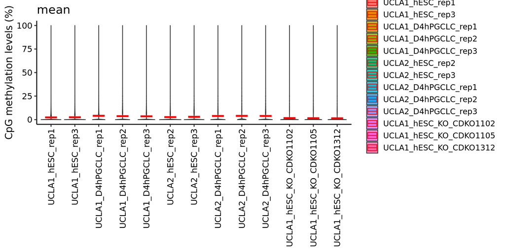

```r
violin_plot(MethPerc_matrix, stat="mean", subset = 3000000) #+ ggplot2::scale_fill_manual(values = sample_colors)
## Subsetting taking random CpGs
## No id variables; using all as measure variables
```

## 3.4 Violin Plot showing median

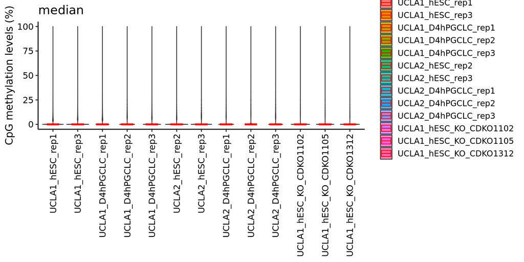

```r
violin_plot(MethPerc_matrix, subset = 3000000) #+ ggplot2::scale_fill_manual(values = sample_colors)
## Subsetting taking random CpGs
## No id variables; using all as measure variables
```

**Mean values for Coverage**

```r
apply(Cov_matrix, 2, mean, na.rm = TRUE)
```

```
##        UCLA1_hESC_rep1        UCLA1_hESC_rep3    UCLA1_D4hPGCLC_rep1
##              18.949867              14.656110              17.058471
##    UCLA1_D4hPGCLC_rep2    UCLA1_D4hPGCLC_rep3        UCLA2_hESC_rep2
##              10.312723              11.888623              12.704628
##        UCLA2_hESC_rep3    UCLA2_D4hPGCLC_rep1    UCLA2_D4hPGCLC_rep2
##              10.051916               9.910634               7.491432
##    UCLA2_D4hPGCLC_rep3 UCLA1_hESC_KO_CDKO1102 UCLA1_hESC_KO_CDKO1105
##              10.262596               6.193677               6.849366
## UCLA1_hESC_KO_CDKO1312
##               7.953816
```

**Median values for Coverage**

```r
apply(Cov_matrix, 2, median, na.rm = TRUE)
```

```
##        UCLA1_hESC_rep1        UCLA1_hESC_rep3    UCLA1_D4hPGCLC_rep1
##                     19                     15                     17
##    UCLA1_D4hPGCLC_rep2    UCLA1_D4hPGCLC_rep3        UCLA2_hESC_rep2
##                     10                     12                     13
##        UCLA2_hESC_rep3    UCLA2_D4hPGCLC_rep1    UCLA2_D4hPGCLC_rep2
##                     10                     10                      7
##    UCLA2_D4hPGCLC_rep3 UCLA1_hESC_KO_CDKO1102 UCLA1_hESC_KO_CDKO1105
##                     10                      6                      7
## UCLA1_hESC_KO_CDKO1312
##                      8
```

**Mean values for Methylation Proportions**

```r
apply(MethPerc_matrix, 2, mean, na.rm = TRUE)
```

```
##        UCLA1_hESC_rep1        UCLA1_hESC_rep3    UCLA1_D4hPGCLC_rep1
##               2.395617               2.515441               4.120048
##    UCLA1_D4hPGCLC_rep2    UCLA1_D4hPGCLC_rep3        UCLA2_hESC_rep2
##               3.698001               3.540895               2.695498
##        UCLA2_hESC_rep3    UCLA2_D4hPGCLC_rep1    UCLA2_D4hPGCLC_rep2
##               3.022686               3.901569               4.024746
##    UCLA2_D4hPGCLC_rep3 UCLA1_hESC_KO_CDKO1102 UCLA1_hESC_KO_CDKO1105
##               3.919115               1.641083               1.529154
## UCLA1_hESC_KO_CDKO1312
##               1.433811
```

**Median values for Methylation Proportions**

```r
apply(MethPerc_matrix, 2, median, na.rm = TRUE)
```

```
##        UCLA1_hESC_rep1        UCLA1_hESC_rep3    UCLA1_D4hPGCLC_rep1
##                      0                      0                      0
##    UCLA1_D4hPGCLC_rep2    UCLA1_D4hPGCLC_rep3        UCLA2_hESC_rep2
##                      0                      0                      0
##        UCLA2_hESC_rep3    UCLA2_D4hPGCLC_rep1    UCLA2_D4hPGCLC_rep2
##                      0                      0                      0
##    UCLA2_D4hPGCLC_rep3 UCLA1_hESC_KO_CDKO1102 UCLA1_hESC_KO_CDKO1105
##                      0                      0                      0
## UCLA1_hESC_KO_CDKO1312
##                      0
```

## 3.5 PCA plots

```r
pca_res <- do_PCA(MethPerc_matrix)
```

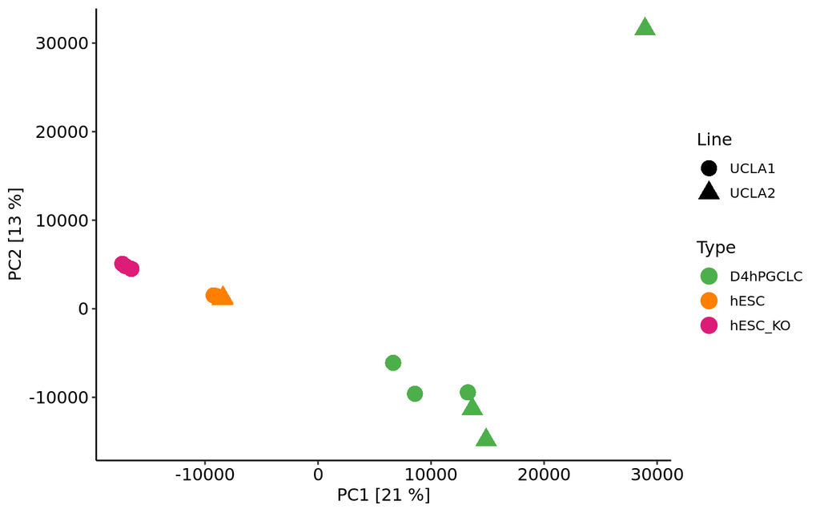

```r
plot_PCA(pca_res = pca_res, anno = sample_anno, col_anno = "Type", shape_anno = "Line", custom_colors = cellTypes_colors, point_size = 5)
```

# 4. Filtering BSSeq object by shared CpGs

```r
table(sample_anno$Type)
```

```
##
## D4hPGCLC     hESC  hESC_KO
##        6        4        3
```

```r
dim(methylSig::filter_loci_by_group_coverage(
    bs = bsseq_obj,
    group_column = 'Type',
    min_samples_per_group = c('D4hPGCLC' = 6, 'hESC' = 4, 'hESC_KO' = 3)))[1]
```

```
## [1] 31697943
```

```r
#length(which(apply(X = is.na(getMeth(bsseq_obj, type="raw")), MARGIN = 1, FUN = sum) == 0)) #26830070
```

- The number of samples in the BSSeq object is 13.
- The number of CpGs in the BSSeq object is 54853237.
- The number of CpGs covered by at least 50% of samples in the BSSeq object is 52457938.
- The number of CpGs covered by at least 75% of samples in the BSSeq object is 49562728.
- The number of CpGs covered by all samples in the BSSeq object is 31697943.
- The number of CpGs covered by at least 60% of samples of the same type in the BSSeq object is 46143123.

# 5. Saving and Session Info

Saving BSSeq objects :

- Complete

```r
saveRDS(bsseq_obj, file = paste0 (OutputFolder, "bsseq_obj_complete.rds"))
```

- Filtered by sample and by CpGs covered by all samples kept

```r
pData(bsseq_obj)$Seq <- "WGBS"
saveRDS(methylSig::filter_loci_by_group_coverage(bs = bsseq_obj,group_column = "Seq", min_samples_per_group = c("WGBS" = dim(bsseq_obj)[2])), file = paste0 (OutputFolder, "bsseq_obj_sharedbyall.rds")) #same of doing group_column = 'Type', min_samples_per_group = c('D4hPGCLC' = 6, 'hESC' = 4, 'hESC_KO' = 3))
```

- With CpGs covered by 75% of all samples kept (independently on cell types)

```r
saveRDS(methylSig::filter_loci_by_group_coverage(bs = bsseq_obj,group_column = "Seq", min_samples_per_group = c("WGBS" = round(0.75*dim(bsseq_obj)[2], digits=0))), file = paste0 (OutputFolder, "bsseq_obj_sharedby75ofall.rds"))
```

- With CpGs covered by at least 60% of samples of the same cell type

```r
saveRDS(methylSig::filter_loci_by_group_coverage(bs = bsseq_obj,group_column = "Type", min_samples_per_group = c('D4hPGCLC' = 4, 'hESC' = 3, 'hESC_KO' = 2)), file = paste0 (OutputFolder, "bsseq_obj_sharedby60CellType.rds"))
```

Session Info

```r
SessionInfo <- sessionInfo()
Date <- date()
```

```r
Date
```

```
## [1] "Tue Apr 29 13:50:08 2025"
```

```r
SessionInfo
```